# LIME for explaining prediction on the Titanic dataset

author: Witalis Domitrz witekdomitrz@gmail.com

I include the plots in static format to make it possible to read this as a static file.

## Preparation

### Install modules

```python
!pip3 install lime
```

### Download the data

```python
!wget http://students.mimuw.edu.pl/~wd393711/iml/titanic.zip
!unzip -o titanic.zip
!rm titanic.zip
```

### Prepare the data

```python
import numpy as np
import pandas as pd

used_columns = ['Pclass', 'Sex', 'Age', 'SibSp', 'Parch', 'Fare', 'Embarked', 'Survived']
X_columns = ['Pclass', 'Age', 'SibSp', 'Parch', 'Fare', 'Sex_male', 'Embarked_C', 'Embarked_Q', 'Embarked_S']
Y_columns = ['Survived']

def load_data(fn):
    return pd.read_csv(fn).set_index('PassengerId')

def to_array(data):
    return pd.get_dummies(data).astype(dtype='float32')

def data_preprocessing():
    global train, test
    train = load_data('./train.csv')
    test = load_data('./gender_submission.csv').join(load_data('./test.csv'))

    train['is_train'] = True
    test['is_train'] = False
    data = pd.concat([train, test])

    # Replace missing values with mean
    data.fillna(data.mean(), inplace=True)

    # Split test and train
    train, test = data[data['is_train']], data[data['is_train'] == False]

    # No unused columns
    train, test = train[used_columns], test[used_columns]

    train, test = to_array(train), to_array(test)
data_preprocessing()


def split_to_x_y(data):
    return to_array(data[X_columns]), to_array(data[Y_columns])

def get_data():
    return split_to_x_y(train), split_to_x_y(test)

def unlabel_data(*sets):
    return ((part.values for part in subset) for subset in sets)
```

```python
(train_x, train_y), (test_x, test_y) = get_data()
```

## 1.

For the selected data set, train a predictive model

```python
from xgboost import XGBClassifier as Model
```

### Create a model

```python
model = Model(max_depth=4)
```

### Train a model

```python
model.fit(train_x.values, train_y)
```

### Check the first model accuracy

```python
from sklearn.metrics import accuracy_score
test_pred = model.predict(test_x.values)
test_accuracy1 = accuracy_score(test_y, [round(value) for value in test_pred])
print("Test accuracy of the first model: {}".format(test_accuracy1))
```

```
Test accuracy of the first model: 0.8827751196172249
```

## 2.

for some selected observation from this dataset, calculate the model predictions for model (1)

### Select an observation

```python
def select_an_observation(id):
    obs = test.loc[[id]]
    x, y = split_to_x_y(obs)
    return (x, y), obs
```

```python
(x2, y2), obs2 = select_an_observation(894)
```

```python
obs2
```

| PassengerId | Pclass | Age | SibSp | Parch | Fare | Survived | Sex_female | Sex_male | Embarked_C | Embarked_Q | Embarked_S |
| --- | --- | --- | --- | --- | --- | --- | --- | --- | --- | --- | --- |
| 894 | 2.0 | 62.0 | 0.0 | 0.0 | 9.6875 | 0.0 | 0.0 | 1.0 | 0.0 | 1.0 | 0.0 |

### Calculate the model predictions

```python
pred2 = model.predict_proba(x2.values)
print("The model preadictet that this person would survive with probability:", pred2[0][1], "and the truth is:", y2.values[0,0])
```

```
The model preadictet that this person would survive with probability: 0.10084572 and the truth is: 0.0
```

## 3.

for an observation selected in (2), calculate the decomposition of model prediction using LIME / live / lime / localModel or similar technique (packages for R: live, live, localModel, iml, packages for python: lime).

### Use lime

```python
from lime.lime_tabular import LimeTabularExplainer as Explainer
```

### Create an explainer

```python
explainer = Explainer(test_x, feature_names=test_x.columns, class_names=['Died', 'Survived'], discretize_continuous=False, verbose=True)
```

### Create an explainer function using LIME

```python
def explain(x, explainer=explainer, model=model):
    # LIME
    lime = explainer.explain_instance(x.values[0], model.predict_proba)
    lime.show_in_notebook(show_table=True)
```

### Explain using LIME

```python
x3, y3 = x2, y2
print("Real value:")
print(y3)
explain(x3)
```

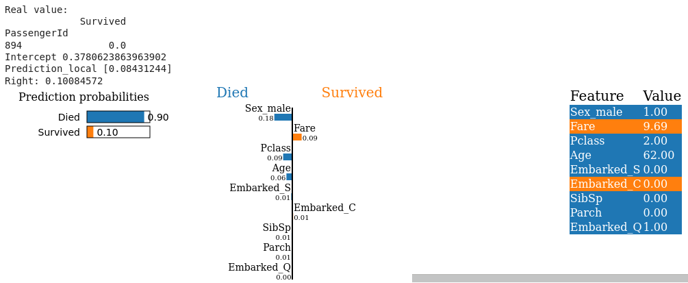

## 4.

compare LIME decompositions for different observations in the dataset. How stable are these explanations?

```python
for i in [1252, 1066, 1296, 1305, 1304, 904, 1158]:
    ((x4, y4), _) = select_an_observation(i)
    print("Real value:")
    print(y4)
    explain(x4)
```

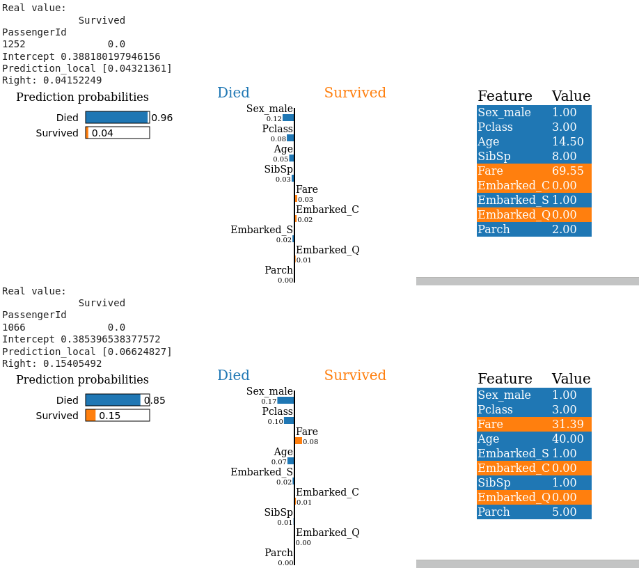

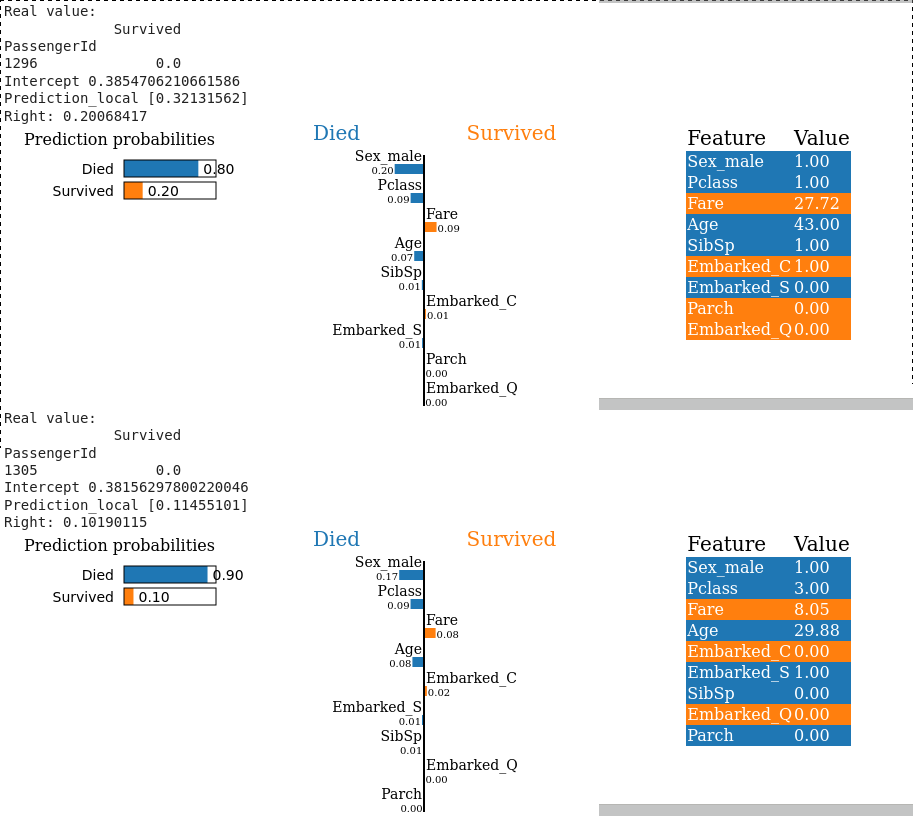

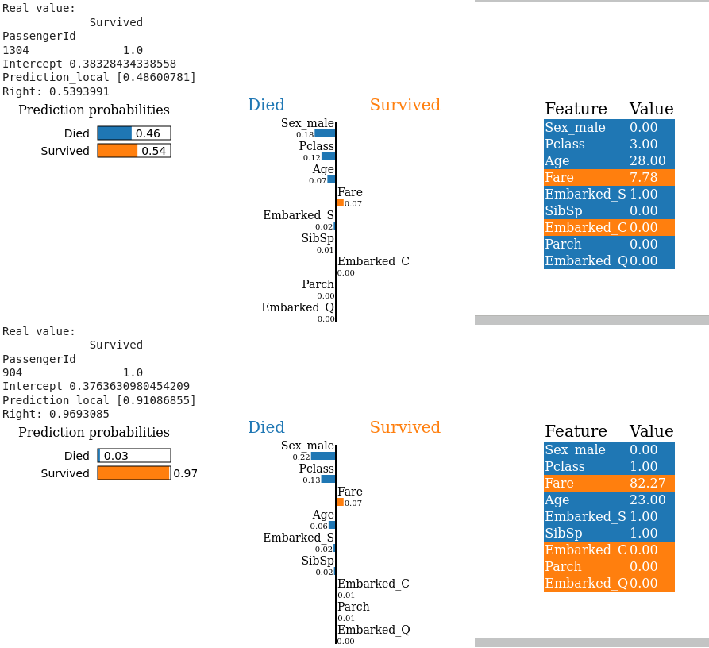

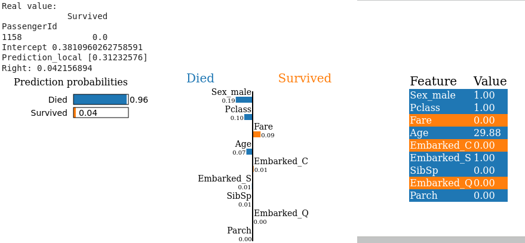